# Linear Regression

KwH. Kim

2018년 11월 9일

## 기초 통계학

- 통계학의 두 가지 주제: 서술 통계(descriptive statistics), 추론 통계(inferential statistics)
- 모집단(population)/표본(sample)
- 모수(parameter)/추정량(estimator)
- 모수의 예
  - 통계 요약치
    - 집중경향치 : 평균(mean), 중앙값(median), 최빈값(mode), 절사평균(trimmed mean)
    - 변산성 측정치 : 범위(range), 사분점간 범위(inter-quartile range), 분산(variance)
- 모평균의 추정방법(모평균 추정량)
  - 표본 평균
  - 표본 중앙값
- 추정량의 좋은 성질
  - 비편향성(unbiasedness)
  - 일치성(consistency)
  - 효율성(efficiency)
- 가설 검정
  - 영가설(귀무가설; null hypothesis), 검정통계량(test statistics)
  - 유의수준(significance level), 오류율(error rate), 기각역(critical region)
  - 효과크기(effect size)
  - 검정력(power)

## 예: 모평균 추정하기

```r
print(getwd())
```

```
## [1] "C:/Users/Jang/Desktop/Coding Program/r/project/MJU-2018-02-DataScience/00_Instructor/W10_LinearRegression"
```

```r
#dat <- read.csv(file='./00_Instructor/W10_LinearRegression/LR_weight_n100.csv', header=T, row.names=1)
#dat <- read.csv(file='./W10_LinearRegression/LR_weight_n100.csv', header=T, row.names=1)
dat <- read.csv(file='./LR_weight_n100.csv', header=T, row.names=1)
t.test(dat$height)
```

```
##
##  One Sample t-test
##
## data:  dat$height
## t = 204.3, df = 99, p-value < 2.2e-16
## alternative hypothesis: true mean is not equal to 0
## 95 percent confidence interval:
##  166.2817 169.5433
## sample estimates:
## mean of x
##  167.9125
```

```r
t.test(dat$weight)
```

```
##
##  One Sample t-test
##
## data:  dat$weight
## t = 35.635, df = 99, p-value < 2.2e-16
## alternative hypothesis: true mean is not equal to 0
## 95 percent confidence interval:
##  69.84168 78.07820
## sample estimates:
## mean of x
##  73.95994
```

## 예: 모평균의 차이 추정하기

```r
t.test(height ~ gender, dat)
```

```
##
##  Welch Two Sample t-test
##
## data:  height by gender
## t = -5.8198, df = 90.205, p-value = 8.887e-08
## alternative hypothesis: true difference in means is not equal to 0
## 95 percent confidence interval:
##  -10.77773  -5.29217
## sample estimates:
## mean in group F mean in group M
##        163.4933        171.5282
```

```r
t.test(weight ~ gender, dat)
```

```
##
##  Welch Two Sample t-test
##
## data:  weight by gender
## t = -11.089, df = 96.576, p-value < 2.2e-16
## alternative hypothesis: true difference in means is not equal to 0
## 95 percent confidence interval:
##  -35.98621 -25.05924
## sample estimates:
## mean in group F mean in group M
##        57.17244        87.69517
```

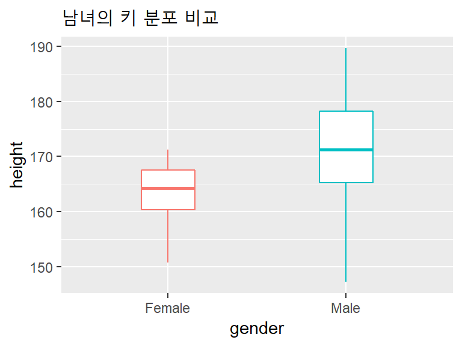

```r
ggplot(dat, aes(x=gender, y=height, col=gender)) +
  #geom_point(alpha=0.2, col='black') +
  geom_boxplot(width=0.3) +
  #geom_boxplot(width=0.3, alpha=0.2) +
  guides(colour='none', fill='none') +
  scale_x_discrete(labels=c('Female', 'Male')) +
  labs(title='남녀의 키 분포 비교')
```

## 회귀(Regression) 분석(Analysis)

- 독립변수(independent variable), 종속변수(dependent variable)
- 설명변수(Explanatory variable), 반응변수(Response variable)
- 예측변수(Predictor variable), 결과변수(Outcome variable)

$$\mathbb{E}[Y | x_1, x_2, ..., x_p] = f(x_1, x_2, ..., x_p)$$

## 단순선형회귀(Simple Linear Regression) 분석

### 모형

$$y= \beta_0 + \beta_1 x + e, e \sim N(0, \sigma^2)$$
$$E[Y | x] = \beta_0 + \beta_1 x + e$$

### 가정(LINE)

- **L**inearity(선형성)
- **I**ndependence(독립성)
- **N**ormality(정규성)
- **E**qual variance(등분산성)

```r
library(ggplot2)
getwd()
```

```
## [1] "C:/Users/Jang/Desktop/Coding Program/r/project/MJU-2018-02-DataScience/00_Instructor/W10_LinearRegression"
```

```r
dat <- read.csv(file='./LR_weight_n100.csv', header=T, row.names=1)

# 01. 데이터 살펴보기
ggplot(dat, aes(x=height, y=weight)) + geom_point() + labs(title="01. 데이터 살펴보기")

# 02. 회귀분석
fitLm <- lm(weight ~ height, dat)
print(fitLm)
```

```
##
## Call:
## lm(formula = weight ~ height, data = dat)
##
## Coefficients:
## (Intercept)       height
##    -265.684        2.023
```

```r
print(summary(fitLm))
```

```
##
## Call:
## lm(formula = weight ~ height, data = dat)
##
## Residuals:
##     Min      1Q  Median      3Q     Max
## -29.713  -7.984  -0.474   8.497  33.696
##
## Coefficients:
##              Estimate Std. Error t value Pr(>|t|)
## (Intercept) -265.6840    25.6719  -10.35   <2e-16 ***
## height         2.0227     0.1527   13.25   <2e-16 ***
## ---
## Signif. codes:  0 '***' 0.001 '**' 0.01 '*' 0.05 '.' 0.1 ' ' 1
##
## Residual standard error: 12.49 on 98 degrees of freedom
## Multiple R-squared:  0.6416, Adjusted R-squared:  0.638
## F-statistic: 175.5 on 1 and 98 DF,  p-value: < 2.2e-16
```

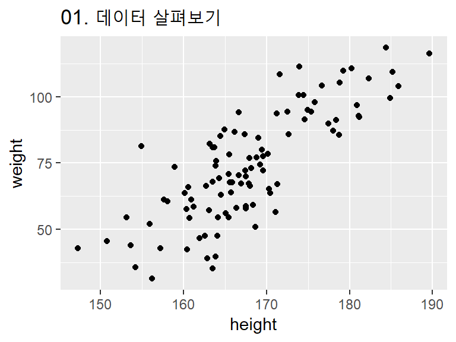

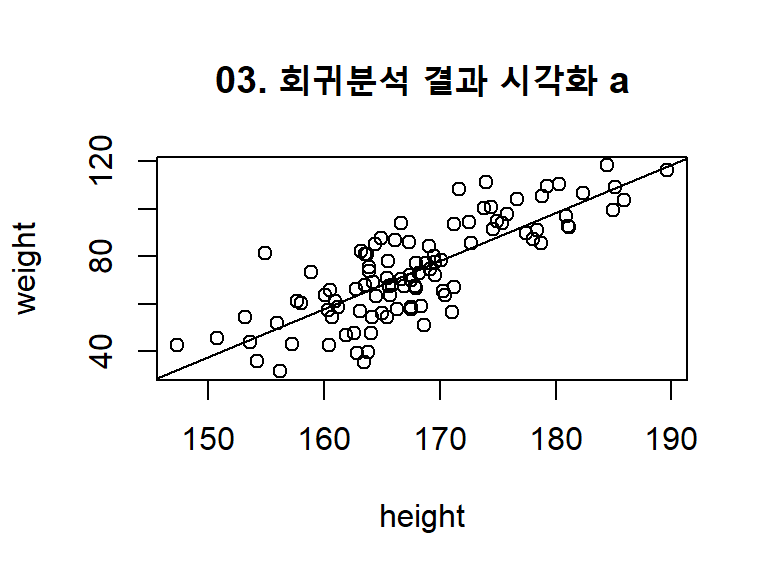

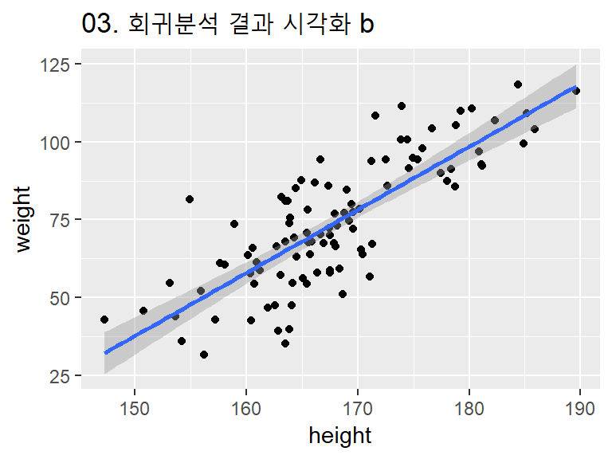

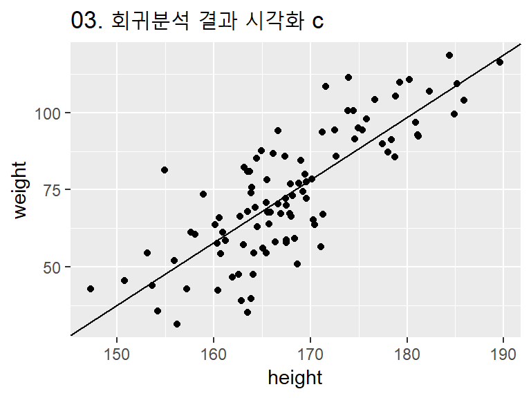

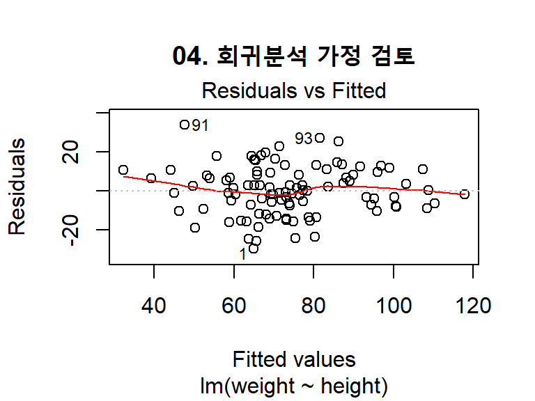

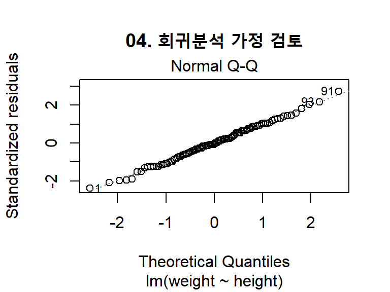

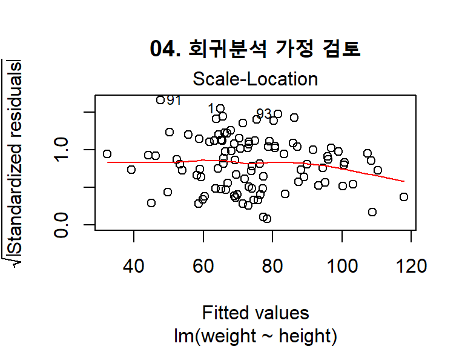

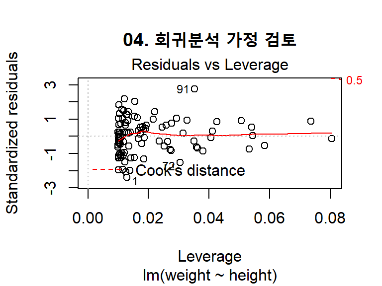

```r
# 03. 회귀분석 결과를 시각화하기
## a
plot(weight ~ height, dat, main='03. 회귀분석 결과 시각화 a'); abline(fitLm)

## b
ggplot(dat, aes(x=height, y=weight)) + geom_point() +
  geom_smooth(method="lm") + labs(title='03. 회귀분석 결과 시각화 b')

## c
ggplot(dat, aes(x=height, y=weight)) + geom_point() +
  geom_abline(intercept = fitLm$coefficients["(Intercept)"],
              slope = fitLm$coefficients["height"]) +
  labs(title='03. 회귀분석 결과 시각화 c')

# 04. 회귀분석 가정 검토
#par(mfrow=c(2,2),oma = c(0, 0, 2, 0))
plot(fitLm, main='04. 회귀분석 가정 검토') # plot(fitLm, which=1:6)
## a. x와 y의 관계가 선형적인가?
## b. 잔차가 정규성을 띄는가?
## c. 잔차가 등분산인가?
## d. 특이값(계수 추정에 큰 영향을 미치는 값)이 존재하는가?
```

### 몇 가지 유의할 부분

- 계수의 크기는 계수의 유의성과 다르다
  - 키와 체중의 관계에서 키 또는 체중의 측정 단위를 달리하면 계수를 임의로 증가 혹은 감소시킬 수 있다.
  - 유의성 여부보다는 **신뢰구간**을 확인한다.

### 문제

- http://data.princeton.edu/wws509/datasets/#salary의 자료를 통해 `sl`와 `yd`의 관계를 선형 회귀로 분석하시오.
- 예측변수와(또는) 결과변수를 변환(transformation)한 후에 회귀 분석을 할 때, 위에서 설명한 LINE 가정은 어떻게 바뀌는지 설명하시오.

### 상관계수(Correlation Coefficient)

$$r_{xy} = \frac{\sum_{i=1}^n (x_i - \hat{x})(y_i - \hat{y})}{(n-1)s_x s_y}$$

- [참고](https://en.wikipedia.org/wiki/Anscombe%27s_quartet)

## 다중선형회귀(Multiple Linear Regression) 분석

### 모형

$$y= \beta_0 + \beta_1 x_1 + \beta_2 x_2 + ... + e, e \sim N(0, \sigma^2)$$

### 가정(LINE)

- **L**inearity(선형성)
- **I**ndependence(독립성)
- **N**ormality(정규성)
- **E**qual variance(등분산성)

```r
library(ggplot2)
getwd()
```

```
## [1] "C:/Users/Jang/Desktop/Coding Program/r/project/MJU-2018-02-DataScience/00_Instructor/W10_LinearRegression"
```

```r
dat <- read.csv(file='00_Instructor/LR_weight_n100.csv', header=T, row.names=1)
```

```r
ggplot(dat, aes(x=height, y=weight)) + geom_point()

# 01. 첫 번째 모형
fitLm01 <- lm(weight ~ height + gender, dat)
print(fitLm01)
```

```
##
## Call:
## lm(formula = weight ~ height + gender, data = dat)
##
## Coefficients:
## (Intercept)       height      genderM
##    -182.379        1.465       18.750
```

```r
print(summary(fitLm01))
```

```
##
## Call:
## lm(formula = weight ~ height + gender, data = dat)
##
## Residuals:
##      Min       1Q   Median       3Q      Max
## -21.8631  -7.3022  -0.0652   7.1842  23.5032
##
## Coefficients:
##              Estimate Std. Error t value Pr(>|t|)
## (Intercept) -182.3786    21.7007  -8.404 3.68e-13 ***
## height         1.4652     0.1325  11.062  < 2e-16 ***
## genderM       18.7499     2.1773   8.612 1.32e-13 ***
## ---
## Signif. codes:  0 '***' 0.001 '**' 0.01 '*' 0.05 '.' 0.1 ' ' 1
##
## Residual standard error: 9.45 on 97 degrees of freedom
## Multiple R-squared:  0.7969, Adjusted R-squared:  0.7927
## F-statistic: 190.3 on 2 and 97 DF,  p-value: < 2.2e-16
```

```r
# 02. 두 번째 모형
fitLm02 <- lm(weight ~ height * gender, dat)
print(fitLm02)
```

```
##
## Call:
## lm(formula = weight ~ height * gender, data = dat)
##
## Coefficients:
##    (Intercept)          height         genderM  height:genderM
##      -141.5100          1.2152        -34.5312          0.3223
```

```r
print(summary(fitLm02))
```

```
##
## Call:
## lm(formula = weight ~ height * gender, data = dat)
##
## Residuals:
##      Min       1Q   Median       3Q      Max
## -21.8626  -7.1918   0.1677   7.4606  23.5542
##
## Coefficients:
##                 Estimate Std. Error t value Pr(>|t|)
## (Intercept)    -141.5100    45.7177  -3.095  0.00258 **
## height            1.2152     0.2795   4.348 3.42e-05 ***
## genderM         -34.5312    52.5081  -0.658  0.51235
## height:genderM    0.3223     0.3174   1.016  0.31238
## ---
## Signif. codes:  0 '***' 0.001 '**' 0.01 '*' 0.05 '.' 0.1 ' ' 1
##
## Residual standard error: 9.448 on 96 degrees of freedom
## Multiple R-squared:  0.7991, Adjusted R-squared:  0.7928
## F-statistic: 127.3 on 3 and 96 DF,  p-value: < 2.2e-16
```

```r
# 03. plot 활용 시각화
plot(weight ~ height, dat, col=gender, main='03. plot 활용 시각화'); abline(fitLm)

# 04. ggplot 활용 시각화
## 04a
ggplot(dat, aes(x=height, y=weight, col=gender)) + geom_point() +
  geom_smooth(method="lm") + labs(title='04. ggplot 활용 시각화 b')

## 04b
ggplot(dat, aes(x=height, y=weight, col=gender)) + geom_point() +
  geom_smooth(method="lm", level=0.95) + labs(title='04. ggplot 활용 시각화 b')

## 04c
ggplot(dat, aes(x=height, y=weight, col=gender)) + geom_point() +
  geom_smooth(method="lm", level=0.6826895) + # pnorm(1) - pnorm(-1)
  labs(title='04. ggplot 활용 시각화 c')

## 04d
ggplot(dat, aes(x=height, y=weight, col=x)) + geom_point() +
  geom_smooth(method="lm", formula = y ~ x * col) +
  labs(title='04. ggplot 활용 시각화 d')
```

```
## Error in FUN(X[[i]], ...): 객체 'x'를 찾을 수 없습니다
```

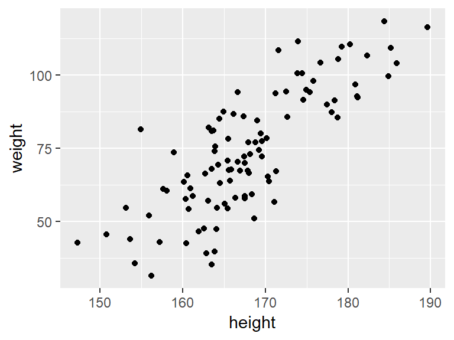

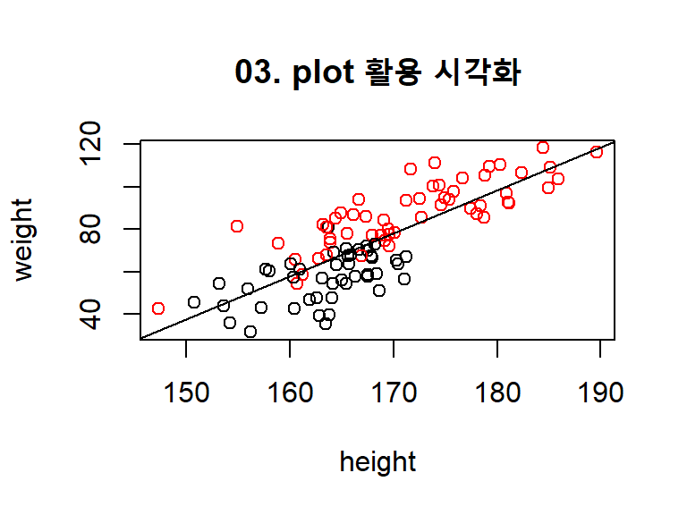

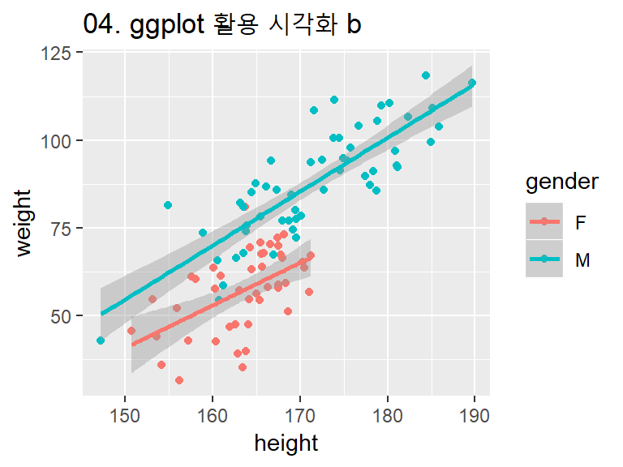

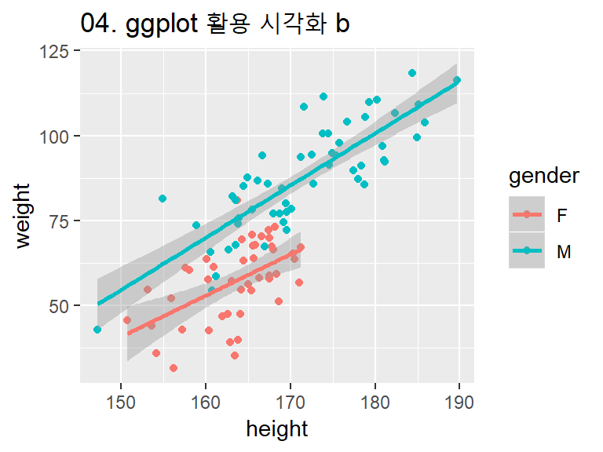

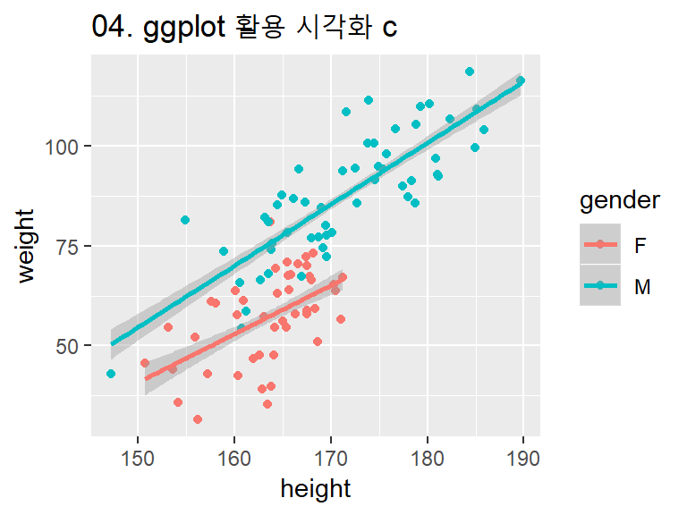

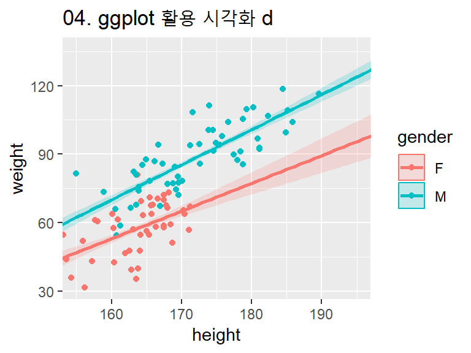

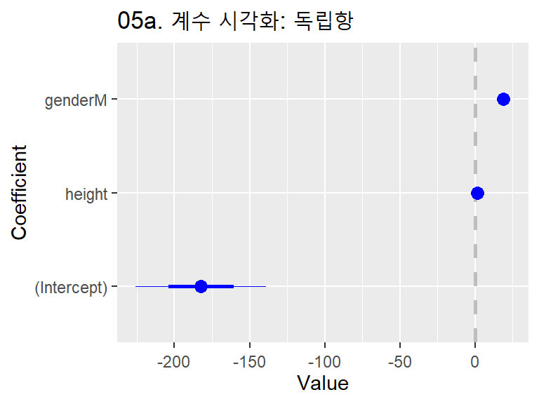

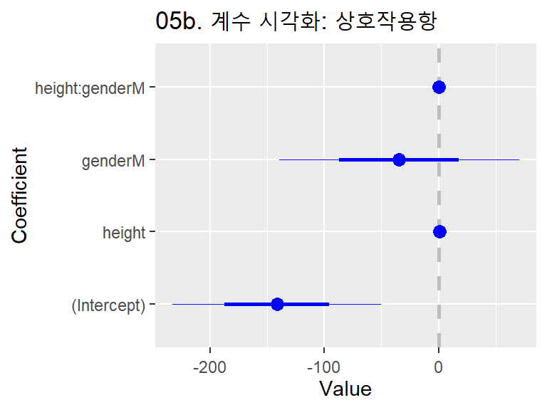

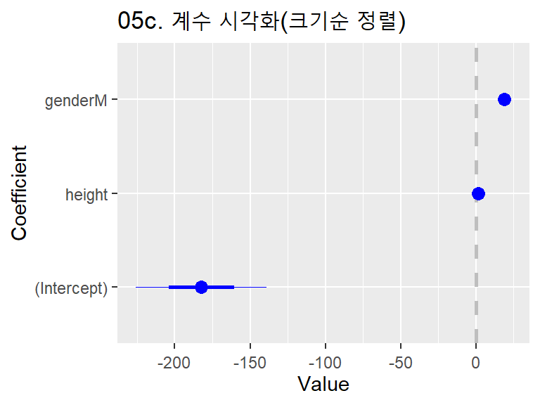

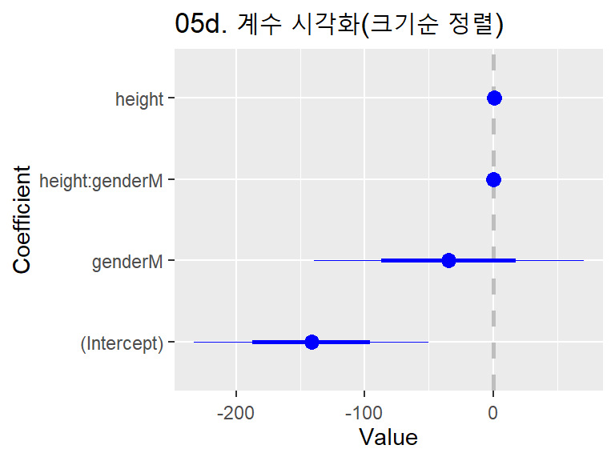

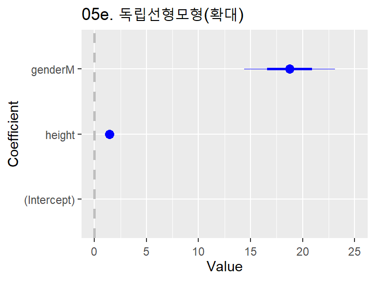

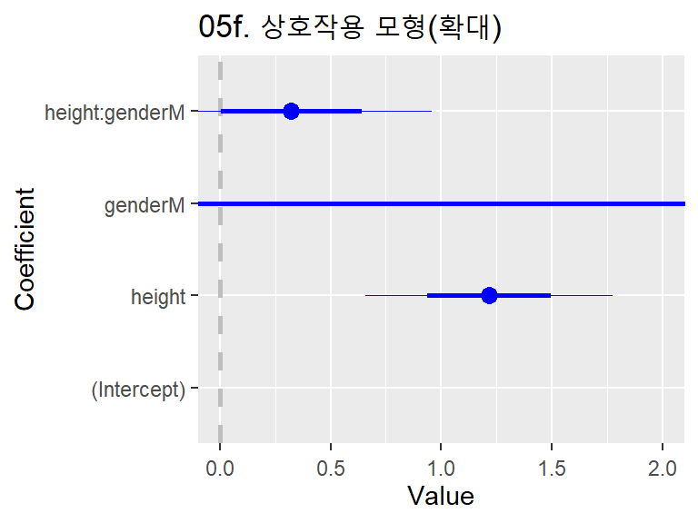

[1 more figures not shown]

```r
## 04e
datPred01 <- data.frame(gender="M", height=150:200)
datPred02 <- data.frame(gender="F", height=150:200)
datPred <- rbind(datPred01, datPred02)
datPred$gender <- factor(as.character(datPred$gender), levels= levels(dat$gender))

pred <- predict(fitLm02, newdata=datPred, se.fit=T)
datPred2 <- data.frame(height=datPred$height, gender=datPred$gender,   # predictor
                       weight = pred$fit,  # prediction
                       weightSE = pred$se.fit)  # SE of prediction

ggplot(dat, aes(x=height, y=weight, col=gender)) + geom_point() +
  geom_ribbon(data=datPred2, aes(x=height,
                                 ymin=weight-weightSE, ymax=weight+weightSE,
                                 col=NULL,
                                 fill=gender), alpha=0.2) +
  geom_line(data=datPred2, aes(x=height, y=weight, col=gender), size=1) +
  coord_cartesian(xlim=c(155,195)) +
  labs(title='04. ggplot 활용 시각화 d')

# 05. 계수 시각화
library(coefplot)
coefplot(fitLm01) + labs(title='05a. 계수 시각화: 독립항')
## b 상호작용 선형 모형
coefplot(fitLm02) + labs(title='05b. 계수 시각화: 상호작용항')

## c 독립 선형 모형
coefplot(fitLm01, sort='mag') + labs(title='05c. 계수 시각화(크기순 정렬)')
## d 상호작용 선형 모형
coefplot(fitLm02, sort='mag') + labs(title='05d. 계수 시각화(크기순 정렬)')

## e 독립 선형 모형(확대)
coefplot(fitLm01) + labs(title='05e. 독립선형모형(확대)') +
  coord_cartesian((xlim=c(0,25)))
## f 상호작용 모형(확대)
coefplot(fitLm02) + labs(title='05f. 상호작용 모형(확대)') +
  coord_cartesian((xlim=c(0,2)))

## g 계수 비교
multiplot(fitLm01, fitLm02) + labs(title='05g. 계수 비교') +
  scale_color_discrete(labels=c('independent', 'interaction')) +
  theme(legend.position = 'bottom') +
  theme(axis.text.x=element_text(angle=0))
## Scale for 'colour' is already present. Adding another scale for
## 'colour', which will replace the existing scale.

library(car)
compareCoefs(fitLm01, fitLm02)
## Calls:
## 1: lm(formula = weight ~ height + gender, data = dat)
## 2: lm(formula = weight ~ height * gender, data = dat)
##
##                Model 1 Model 2
## (Intercept)     -182.4  -141.5
## SE                21.7    45.7
##
## height           1.465   1.215
## SE               0.132   0.279
##
## genderM          18.75  -34.53
## SE                2.18   52.51
##
## height:genderM           0.322
## SE                       0.317
##
compareCoefs(fitLm01, fitLm02, se=F)
## Calls:
## 1: lm(formula = weight ~ height + gender, data = dat)
## 2: lm(formula = weight ~ height * gender, data = dat)
##
##                Model 1 Model 2
## (Intercept)       -182    -142
## height            1.47    1.22
## genderM           18.7   -34.5
## height:genderM           0.322

anova(fitLm01, fitLm02)
## Analysis of Variance Table
##
## Model 1: weight ~ height + gender
## Model 2: weight ~ height * gender
##   Res.Df    RSS Df Sum of Sq      F Pr(>F)
## 1     97 8661.5
## 2     96 8569.4  1    92.071 1.0314 0.3124
```

### Wilkson-Rogers Notation

| 표기 | 표기2 | 수식 |
| --- | --- | --- |
| `y ~ x1 + x2` |  | $\mathbb{E}[\mathbf{y}] = \beta_0 + \beta_1 \mathbf{x1} + \beta_2 \mathbf{x2}$ |
| `y ~ x1 + x2-1` |  | $\mathbb{E}[\mathbf{y}] = \phantom{\beta_0+} \beta_1 \mathbf{x1} + \beta_2 \mathbf{x2}$ |
| `y ~ x1:x2` |  | $\mathbb{E}[\mathbf{y}] = \beta_0 + \beta_1 (\mathbf{x1}\cdot\mathbf{x2})$ |
| `y ~ x1*x2` | `y~x1+x2+x1:x2` | $\mathbb{E}[\mathbf{y}] = \beta_0 + \beta_1 \mathbf{x1} +\beta_2 \mathbf{x2} + \beta_3 (\mathbf{x1}\cdot\mathbf{x2})$ |
| `y ~ I(x1*x2)` | `z=x1*x2; y~z` | $\mathbb{E}[\mathbf{y}] = \beta_0 + \beta_1 (\mathbf{x1}\cdot\mathbf{x2})$ |